# Appendix S5. Heritability and HMSC

# Broad-sense heritability estimates

The work of (Jewell and Bell 2023) includes a reciprocal transplant experiment, which can be used to separate genetic phenotypic variance from other sources (i.e. environmental plasticity). With that, we can include genetic (and in principal environmental and residual plastic) components of trait variation as predictors in the HMSC models.

The quantitative trait of frond area has the following distributions by species:

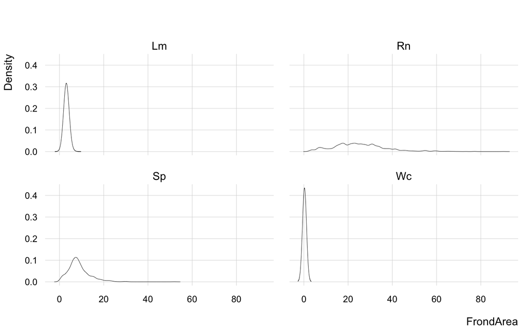

Distribution of frond area ($mm^2$) measured for four aquatic plant species (Lemna minor (Lm), Spirodela polyrhiza (Sp), Wolffia columbiana (Wc), and Ricciocarpos natans (Rn)) in a reciprocal transplant experiment.

```r
## Load in reciprocal transplant data
dat_rt <- read.csv("./data/emp/ReciprocalTransplant.csv")
## Community and Environment as factors
dat_rt$C.Env <- as.factor(dat_rt$C.Env)
dat_rt$E.Env <- as.factor(dat_rt$E.Env)
## Quantitative trait distributions
tinytheme("ipsum")
plt(~FrondArea, type = "density", data = dat_rt, facet = ~Species)
```

We can construct a reaction norm for each species, by considering the mean phenotype for each of nine populations (given in the raw data file as `C.Env`, the environment that the plants were exposed to over 12 weeks) measured in each of the nine environments (given in the raw data file as `E.Env`). The authors of (Jewell and Bell 2023) consider two populations, Derived and Ancestral, and two environments, Modified and Original.

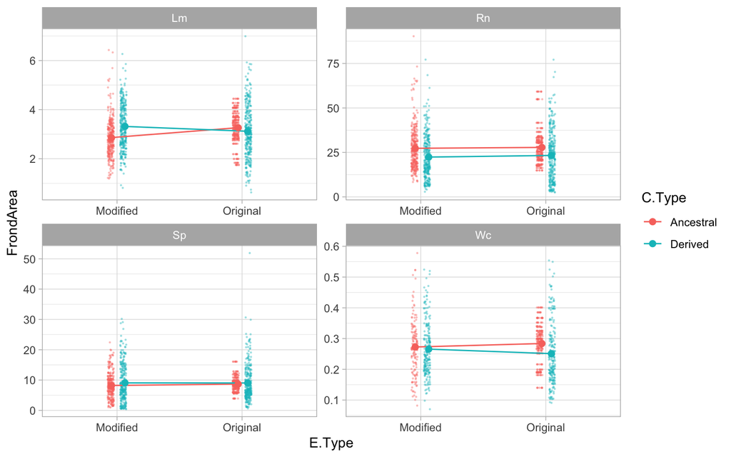

Reaction norm for frond area ($mm^2$) of two populations (Ancestral ad Derived) measured in two environments (Modified and Original), for four aquatic plant species.

```r
ggplot(dat_rt, aes(x = E.Type, y = FrondArea, color = C.Type)) + geom_point(aes(group = C.Type),
    position = position_jitterdodge(0.1, dodge.width = 0.2), alpha = 0.3, size = 0.2) +
    stat_summary(aes(group = C.Type), position = position_jitterdodge(0.1, dodge.width = 0.2),
        fun.y = mean, geom = "path") + stat_summary(aes(color = C.Type), position = position_jitterdodge(0.1,
    dodge.width = 0.2), fun.y = mean, geom = "point", size = 2) + facet_wrap(~Species,
    scales = "free") + theme_light()
```

We instead used the nine populations and environments, with awareness the experiment was not designed to be balanced across these levels. For example, plants that evolved in environment 9 (low light, high nutrients) are considered as population 9. Individuals from this population were placed in reciprocal transplant experiments only in environment 5 (medium light, medium nutrients; considered to be a match to the ancestral environment in the lake where all experimental plants are sourced) and environment 9. Because the environmental treatments vary across three light levels (Low = 3%, Medium = 12%, High = 50%) and three nutrient treatments (dissolved nitrogen and phosphorus, DN, and DP; Low: DN = 200 $\mu g L^{-1}$, DP = 10 $\mu g L^{-1}$; Medium: DN = 800 $\mu g L^{-1}$, DP = 40 $\mu g L^{-1}$; High: 3200 $\mu g L^{-1}$, DP = 160 $\mu g L^{-1}$), we create a single environmental value as the mean phenotype value of all individuals measured in each of the nine environments (Falconer 1989) (Stearns 1992).

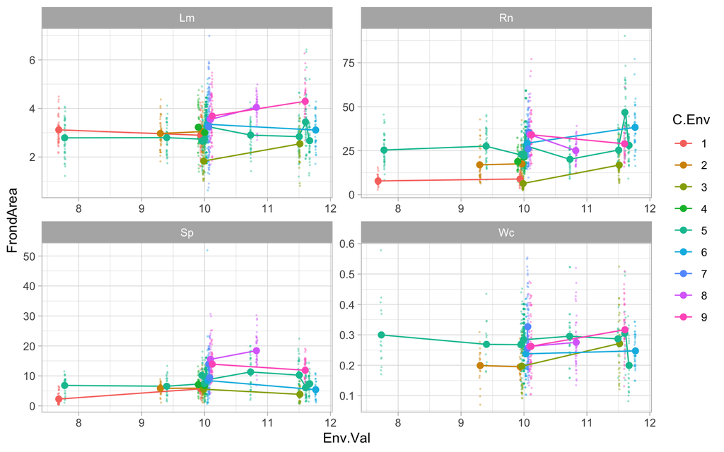

Reaction norm of frond area ($mm^2$) for nine populations (Nutrients: low, medium, high; Light: low, medium, high) measured in nine environments (Nutrients: low, medium, high; Light: low, medium, high), for four aquatic plant species.

```r
# Calculate environmental value (page 136, Falconer 1989; cited in Stearns
# 1992, page 62) Following Jewell & Bell 2023, we define environment 1-9 We
# calculate the mean across all individuals in each of these environments -
# this becomes the 'environmental value' Create environmental value
dat_rt$Env.Val <- NA
Env.Val <- by(dat_rt, factor(dat_rt$E.Env), function(x) {
    mean(x$FrondArea)
})
for (i in 1:length(levels(factor(dat_rt$E.Env)))) {
    dat_rt$Env.Val[dat_rt$E.Env == levels(factor(dat_rt$E.Env))[i]] <- as.numeric(Env.Val[i])
}
# Reaction norm plot
ggplot(dat_rt, aes(x = Env.Val, y = FrondArea, color = C.Env)) + geom_point(aes(group = C.Env),
    position = position_jitterdodge(0.1, dodge.width = 0.2), alpha = 0.3, size = 0.2) +
    stat_summary(aes(group = C.Env), position = position_jitterdodge(0.1, dodge.width = 0.2),
        fun.y = mean, geom = "path") + stat_summary(aes(color = C.Env), position = position_jitterdodge(0.1,
    dodge.width = 0.2), fun.y = mean, geom = "point", size = 2) + facet_wrap(~Species,
    scales = "free") + theme_light()
```

We consider the following linear model and corresponding variance components and heritability estimate ($h^2$ after (Piepho and Möhring 2007)):

$$y = \beta_0 + \beta_1 G + \beta_2 E +
\beta_3 G \times E + \epsilon$$

$$h^2 = \frac{\sigma^2_G}{\sigma^2_G +
\frac{\sigma^2_{GE}}{m} + \frac{\sigma^2}{mr}}$$
Where $G$ is the effect of the genetic component (population in this case), $E$ is the effect of environmental value, $G \times E$ is their interaction, $m$ is the number of environmental levels, and $r$ is the number of replicates. We implemented a mixed model, with $E$ as a fixed effect, and $G$ and $G \times E$ as random effects. The mixed model and estimation of variance terms were carried out using R package `statgenGxE` (van Rossum 2025) (note that the model places the environment term with the residual term).

```r
## Calculate phenotypic variance components in a linear mixed model
dat_rt$Env.Val <- as.factor(dat_rt$Env.Val)
dat_rt$Env.Val <- as.ordered(dat_rt$Env.Val)
Wc <- subset(dat_rt, grepl("Wc", Species))
Sp <- subset(dat_rt, grepl("Sp", Species))
Lm <- subset(dat_rt, grepl("Lm", Species))
Rn <- subset(dat_rt, grepl("Rn", Species))

## Broad-sense heritability estimates by species Wc
Wc.TD <- statgenSTA::createTD(data = Wc, genotype = "C.Env", trial = "Env.Val")
drops.Wc <- gxeVarComp(TD = Wc.TD, trait = "FrondArea")
var.Wc <- vc(drops.Wc)
h2.Wc <- var.Wc$Component[1]/(var.Wc$Component[1] + (var.Wc$Component[2]/9) + (var.Wc$Component[3]/(9 *
    2)))
# Sp
Sp.TD <- statgenSTA::createTD(data = Sp, genotype = "C.Env", trial = "Env.Val")
drops.Sp <- gxeVarComp(TD = Sp.TD, trait = "FrondArea")
var.Sp <- vc(drops.Sp)
h2.Sp <- var.Sp$Component[1]/(var.Sp$Component[1] + (var.Sp$Component[2]/9) + (var.Sp$Component[3]/(9 *
    2)))
# Lm
Lm.TD <- statgenSTA::createTD(data = Lm, genotype = "C.Env", trial = "Env.Val")
drops.Lm <- gxeVarComp(TD = Lm.TD, trait = "FrondArea")
var.Lm <- vc(drops.Lm)
h2.Lm <- var.Lm$Component[1]/(var.Lm$Component[1] + (var.Lm$Component[2]/9) + (var.Lm$Component[3]/(9 *
    2)))
# Rn
Rn.TD <- statgenSTA::createTD(data = Rn, genotype = "C.Env", trial = "Env.Val")
drops.Rn <- gxeVarComp(TD = Rn.TD, trait = "FrondArea")
var.Rn <- vc(drops.Rn)
h2.Rn <- var.Rn$Component[1]/(var.Rn$Component[1] + (var.Rn$Component[2]/9) + (var.Rn$Component[3]/(9 *
    2)))
```

We can now implement these values into the HMSC, to estimate the impact of trait evolution (as well as other predictors) for species abundances.

# References

Falconer, D. S. 1989. Introduction to quantitative genetics. Longman Scientific & Technical London.

Jewell, M. D., and G. Bell. 2023. [Eco-evolutionary contributions to community trait change in floating aquatic plants](https://doi.org/10.1002/ecy.4117). Ecology 104:e4117.

Piepho, H.-P., and J. Möhring. 2007. Computing heritability and selection response from unbalanced plant breeding trials. Genetics 177:1881–1888.

Stearns, S. C. 1992. The evolution of life histories. Oxford University Press.

van Rossum, B.-J. 2025. [statgenGxE: Genotype by environment (GxE) analysis](https://CRAN.R-project.org/package=statgenGxE).

[^1]: Université Marie et Louis Pasteur, CNRS, Chrono-environnement (UMR 6249), F-25000 Besançon, France, jelena.pantel@umlp.fr
[^2]: Aquatic Ecology and Evolution Group, Limnological Institute, Department of Biology, University of Konstanz, Universitaetsstrasse 10, 78464 Konstanz, Germany, ruben.hermann@posteo.de